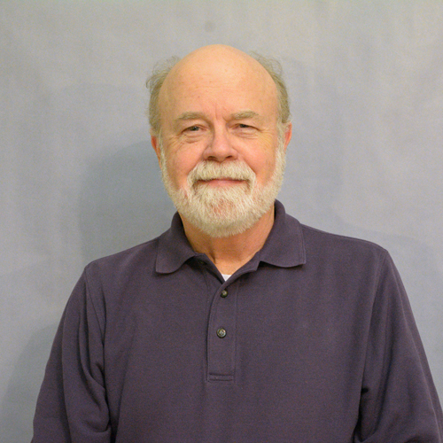

**William H. Woodall** is Professor Emeritus of Statistics at Virginia Tech. He is a former Editor of the Journal of Quality Technology (2001–2003) and Associate Editor of Technometrics (1987–1995). He has published over 160 refereed journal papers, most on various aspects of process monitoring. He is the recipient of the ASQ Shewhart Medal (2002), ENBIS Box Medal (2012), William G. Hunter Award (2019), Jack Youden Prize (1995, 2003), ASQ Brumbaugh Award (2000, 2006), Ellis Ott Foundation Award (1987), Soren Bisgaard Award (2012), Lloyd S. Nelson Award (2014), and an IIE Transactions on Quality and Reliability Engineering best paper award (1997). He is a Fellow of the American Statistical Association, a Fellow of the American Society for Quality, and an elected member of the International Statistical Institute. Current research interests include sampling issues related to process monitoring, risk-adjusted outcome monitoring in healthcare applications, and social network monitoring.

**Institution**: Virginia Tech, Blacksburg, Virginia, United States

**Keywords**: statistical process Monitoring, nonparametric statistics, change-point analysis.

**Pages**: [University profile](https://www.stat.vt.edu/people/stat-faculty/woodall-bill.html), download Short vitae, [Researchgate](https://www.researchgate.net/profile/William_Woodall), [Google Scholar profile](https://scholar.google.com/citations?user=5y13-1EAAAAJ&hl=es), [Linkedin](https://www.linkedin.com/in/bill-woodall-b7b9172/).